# Basic genomic regions exploration

Project: Example DiffBind.

# Introduction

This report is meant to help explore a set of genomic regions and was generated using the `regionReport` ([Collado-Torres, Jaffe, and Leek, 2015](http://www.bioconductor.org/packages/release/bioc/html/regionReport.html)) package. While the report is rich, it is meant to just start the exploration of the results and exemplify some of the code used to do so. You will most likely need a more in-depth analysis for your specific data set.

Most plots were made with using `ggplot2` ([Wickham, 2009](http://had.co.nz/ggplot2/book)).

## Code setup

```r
## Warning: package 'AnnotationDbi' was built under R version 3.2.1
```

# Quality checks

## Q-values

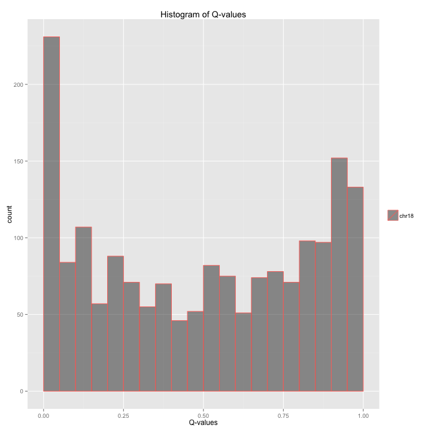

```r
##      Min.   1st Qu.    Median      Mean   3rd Qu.      Max.
## 0.0000089 0.1699000 0.5198000 0.4948000 0.8179000 0.9993000
```

This is the numerical summary of the distribution of the Q-values.

| Cut | Count |
| --- | --- |
| 0.0001 | 7 |
| 0.0010 | 25 |
| 0.0100 | 96 |
| 0.0250 | 160 |
| 0.0500 | 231 |
| 0.1000 | 315 |
| 0.2000 | 479 |
| 0.3000 | 638 |
| 0.4000 | 763 |
| 0.5000 | 861 |
| 0.6000 | 1018 |
| 0.7000 | 1143 |
| 0.8000 | 1292 |
| 0.9000 | 1487 |
| 1.0000 | 1772 |

This table shows the number of regions with Q-values less or equal than some commonly used cutoff values.

## P-values

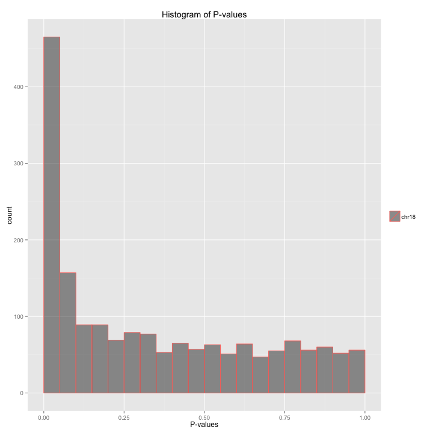

```r
##    Min. 1st Qu.  Median    Mean 3rd Qu.    Max.
## 0.00000 0.04254 0.26030 0.34370 0.61370 0.99930
```

This is the numerical summary of the distribution of the P-values.

| Cut | Count |
| --- | --- |
| 0.0001 | 50 |
| 0.0010 | 120 |
| 0.0100 | 262 |
| 0.0250 | 359 |
| 0.0500 | 465 |
| 0.1000 | 622 |
| 0.2000 | 800 |
| 0.3000 | 948 |
| 0.4000 | 1078 |
| 0.5000 | 1200 |
| 0.6000 | 1314 |
| 0.7000 | 1425 |
| 0.8000 | 1548 |
| 0.9000 | 1664 |
| 1.0000 | 1772 |

This table shows the number of regions with P-values less or equal than some commonly used cutoff values.

## Region width

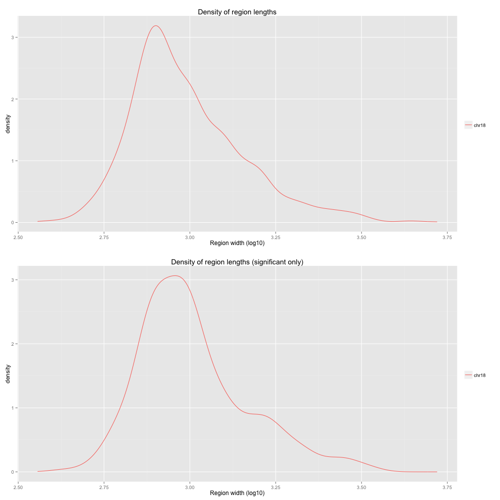

This plot shows the density of the region lengths for all regions. The bottom panel is restricted to significant regions.

## Fold

```r
## stat_bin: binwidth defaulted to range/30. Use 'binwidth = x' to adjust this.
## stat_bin: binwidth defaulted to range/30. Use 'binwidth = x' to adjust this.
```

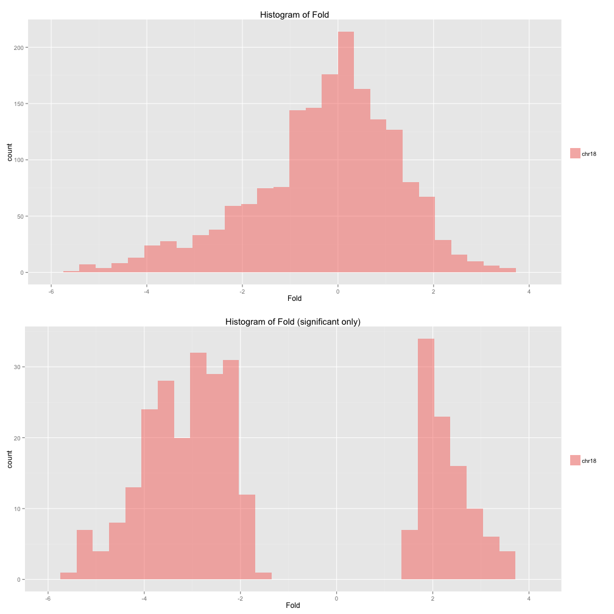

This plot shows the histogram of the Fold for all regions. The bottom panel is restricted to significant regions.

## Mean concentration

```r
## stat_bin: binwidth defaulted to range/30. Use 'binwidth = x' to adjust this.
## stat_bin: binwidth defaulted to range/30. Use 'binwidth = x' to adjust this.
```

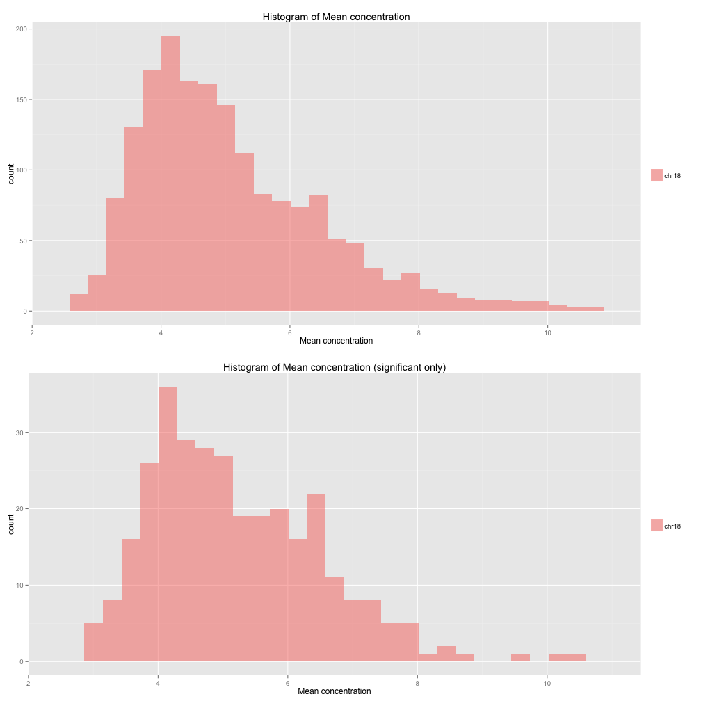

This plot shows the histogram of the Mean concentration for all regions. The bottom panel is restricted to significant regions.

## Concentration (resistant)

```r
## stat_bin: binwidth defaulted to range/30. Use 'binwidth = x' to adjust this.
## stat_bin: binwidth defaulted to range/30. Use 'binwidth = x' to adjust this.
```

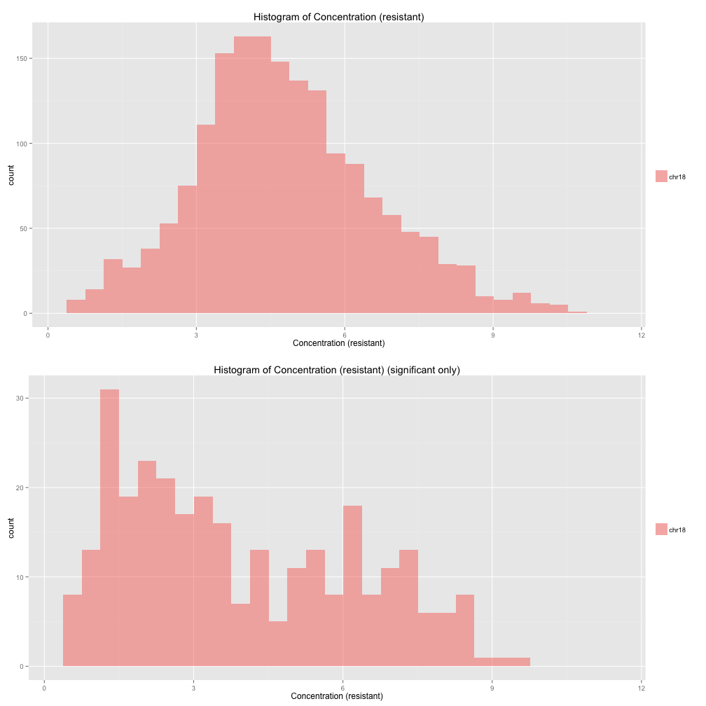

This plot shows the histogram of the Concentration (resistant) for all regions. The bottom panel is restricted to significant regions.

## Concentration (responsive)

```r
## stat_bin: binwidth defaulted to range/30. Use 'binwidth = x' to adjust this.
## stat_bin: binwidth defaulted to range/30. Use 'binwidth = x' to adjust this.
```

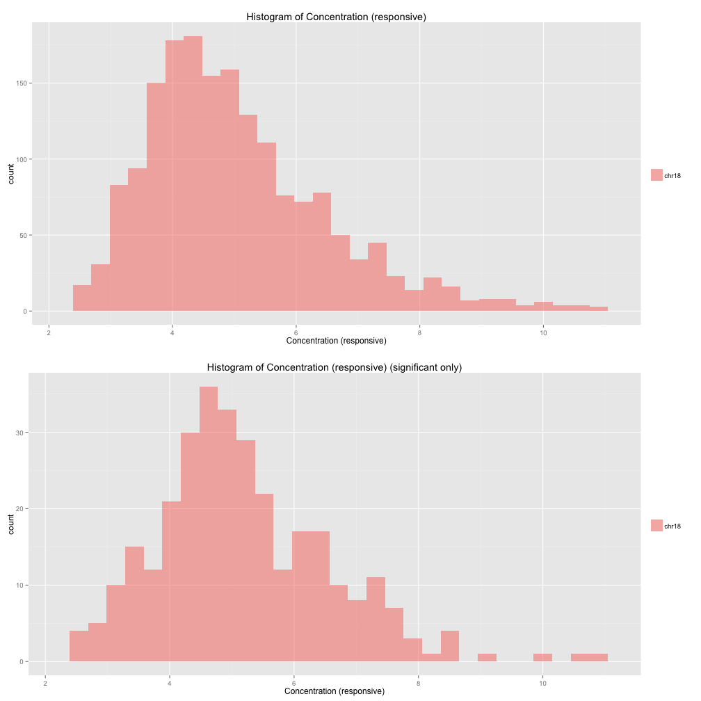

This plot shows the histogram of the Concentration (responsive) for all regions. The bottom panel is restricted to significant regions.

# Genomic overview

The following plots were made using `ggbio` (Yin, Cook, and Lawrence, 2012) which in turn uses `ggplot2` ([Wickham, 2009](http://had.co.nz/ggplot2/book)). For more details check `plotOverview` in `derfinderPlot` ([Collado-Torres, Jaffe, and Leek, 2015](http://www.bioconductor.org/packages/release/bioc/html/derfinderPlot.html)).

## P-values

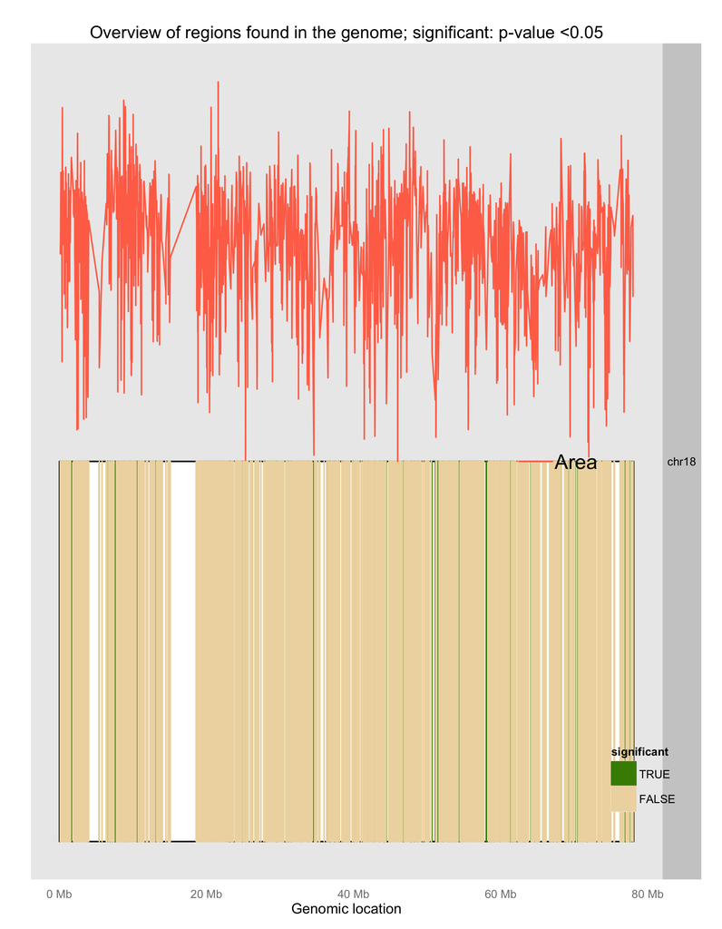

## Manhattan Q-values

```r
## using coord:genome to parse x scale
```

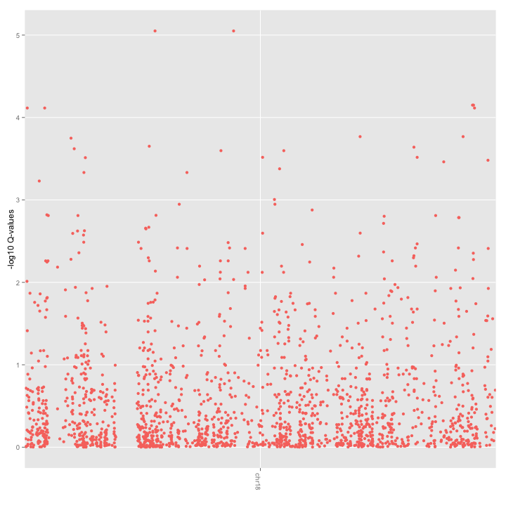

This is a Manhattan plot for the Q-values for all regions. A single dot is shown for each region, where higher values in the y-axis mean that the Q-values are closer to zero.

## Manhattan P-values

```r
## using coord:genome to parse x scale
```

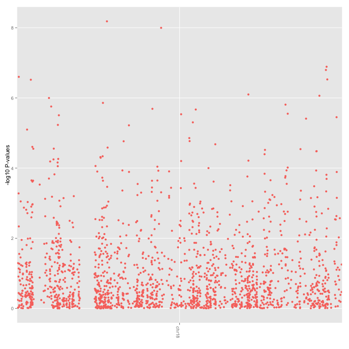

This is a Manhattan plot for the P-values for all regions. A single dot is shown for each region, where higher values in the y-axis mean that the P-values are closer to zero.

## Annotation

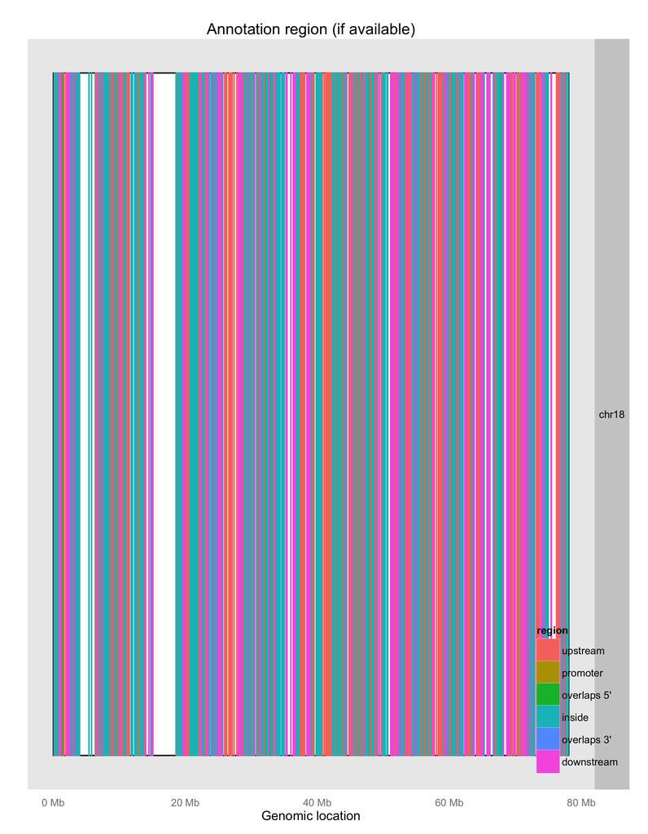

This genomic overview plot shows the annotation region type for the regions as determined using `bumphunter` ([Jaffe, Murakami, Lee, Leek, et al., 2012](http://dx.doi.org/10.1093/ije/dyr238)). Note that the regions are shown only if the annotation information is available. Below is a table of the actual number of results per annotation region type.

| Region | Count |
| --- | --- |
| upstream | 461 |
| promoter | 11 |
| overlaps 5' | 35 |
| inside | 817 |
| overlaps 3' | 7 |
| close to 3' | 0 |
| downstream | 441 |
| covers | 0 |
| NA | 0 |

## Annotation (significant)

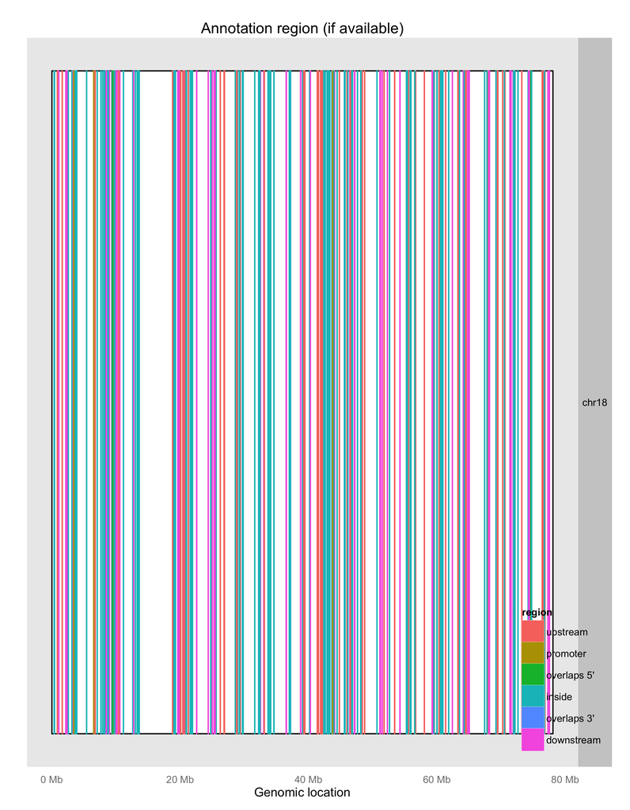

This genomic overview plot shows the annotation region type for the statistically significant regions. Note that the regions are shown only if the annotation information is available.

# Best regions

## Genomic states

Below is a table summarizing the number of genomic states per region as determined using `derfinder` ([Collado-Torres, Frazee, Love, Irizarry, et al., 2015](http://www.biorxiv.org/content/early/2015/02/19/015370.abstract)).

```r
## 'select()' returned 1:1 mapping between keys and columns
```

| Number of Overlapping States | Frequency | State |
| --- | --- | --- |
| 0 | 1621 | exon |
| 1 | 129 | exon |
| 2 | 19 | exon |
| 3 | 3 | exon |
| 0 | 834 | intergenic |
| 1 | 936 | intergenic |
| 2 | 2 | intergenic |
| 0 | 913 | intron |
| 1 | 762 | intron |
| 2 | 87 | intron |
| 3 | 10 | intron |

The following is a venn diagram showing how many regions overlap known exons, introns, and intergenic segments, none of them, or multiple of these groups.

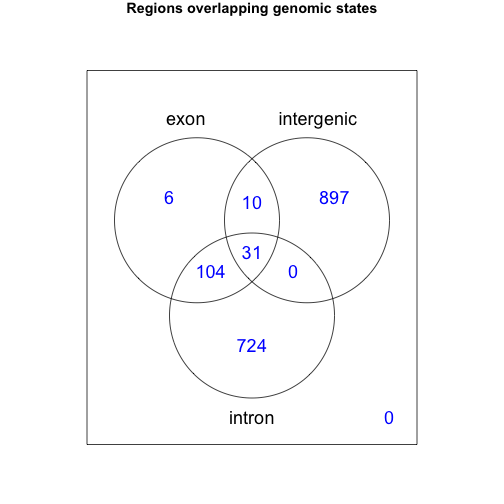

The following plot is the genomic states venn diagram only for the significant regions.

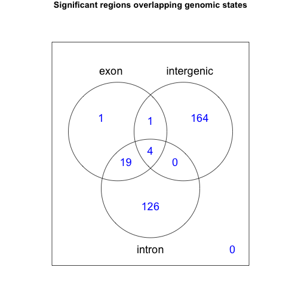

## Region information

Below is an interactive table with the top 100 regions (out of 1772) as ranked by p-value . Inf and -Inf are shown as 1e100 and -1e100 respectively.

pvalueRank

seqnames

start

end

width

strand

Conc

Conc_Resistant

Conc_Responsive

Fold

p.value

FDR

name

annotation

description

region

distance

subregion

insideDistance

exonnumber

nexons

UTR

strand

geneL

codingL

Entrez

subjectHits

1

chr18

21575222

21575958

737

5.418829

6.7440548

2.578081

4.165974

0.0000000

0.0000089

TTC39C

NM_001135993 NM_001243425 NM_001292030 NM_153211 NP_001129465 NP_001230354 NP_001278959 NP_694943 XM_005258198 XM_006722392 XM_011525814 XP_005258255 XP_006722455 XP_011524116

inside intron

inside

2485

inside intron

-2219

1

14

5' UTR

142837

NA

125488

9739

2

chr18

34597337

34598560

1224

5.729605

0.5547330

6.367085

-5.812352

0.0000000

0.0000089

KIAA1328

NM_020776 NP_065827 XM_005258315 XM_005258317 XM_005258318 XM_005258319 XM_005258321 XM_011526099 XM_011526100 XM_011526101 XM_011526102 XM_011526103 XM_011526104 XM_011526105 XM_011526106 XM_011526107 XP_005258372 XP_005258374 XP_005258375 XP_005258376 XP_005258378 XP_011524401 XP_011524402 XP_011524403 XP_011524404 XP_011524405 XP_011524406 XP_011524407 XP_011524408 XP_011524409 XR_935236 XR_935237 XR_935238

inside intron

inside

188257

inside intron

48292

7

10

inside transcription region

396208

NA

57536

48793

3

chr18

74368318

74370013

1696

7.840210

3.4364354

8.467287

-5.030851

0.0000001

0.0000708

LINC00908

NR_015417

downstream

downstream

127706

NA

NA

NA

3

NA

31172

NA

284276

26489

4

chr18

74204609

74206140

1532

4.743714

0.7680540

5.362053

-4.593999

0.0000002

0.0000708

ZNF516

NM_014643 NP_055458 XM_011526269 XM_011526270 XM_011526271 XM_011526272 XM_011526273 XM_011526274 XM_011526275 XM_011526276 XM_011526277 XP_011524571 XP_011524572 XP_011524573 XP_011524574 XP_011524575 XP_011524576 XP_011524577 XP_011524578 XP_011524579 XR_935268

inside intron

inside

1006

inside intron

959

1

8

5' UTR

137509

NA

9658

72102

5

chr18

394600

396513

1914

6.810027

8.0569274

4.594123

3.462805

0.0000003

0.0000767

COLEC12

NM_030781 NM_130386 NP_569057 XM_011525741 XP_011524043

inside intron

inside

104216

inside intron

-37077

3

10

inside transcription region

181374

NA

81035

63168

6

chr18

74535787

74537517

1731

5.077043

1.3788537

5.688124

-4.309270

0.0000003

0.0000767

ZNF236

NM_007345 NP_031371 XM_005266762 XM_006722541 XM_011526165 XM_011526166 XM_011526167 XM_011526168 XM_011526169 XM_011526170 XP_005266819 XP_006722604 XP_011524467 XP_011524468 XP_011524469 XP_011524470 XP_011524471 XP_011524472

overlaps 5'

overlaps 5'

0

covers exon(s)

0

1

31

overlaps 5' UTR

146566

NA

7776

59391

7

chr18

3283015

3284021

1007

4.469911

0.2460637

5.093635

-4.847571

0.0000003

0.0000767

MYL12B

NM_001144944 NM_001144945 NM_001144946 NM_033546 NP_001138416 NP_001138417 NP_291024

downstream

downstream

20904

NA

NA

NA

4

NA

16171

NA

103910

4630

8

chr18

55568312

55570601

2290

6.346737

2.9161330

6.949320

-4.033187

0.0000008

0.0001706

ATP8B1

NM_005603 NP_005594 XM_006722481 XM_011526020 XM_011526021 XM_011526022 XM_011526023 XM_011526024 XP_006722544 XP_011524322 XP_011524323 XP_011524324 XP_011524325 XP_011524326

upstream

upstream

97985

NA

NA

NA

28

NA

156668

NA

5205

40975

9

chr18

72640857

72641681

825

5.016424

1.0922420

5.633523

-4.541281

0.0000009

0.0001706

ZNF407

NM_001146189 NM_001146190 NM_017757 NP_001139661 NP_001139662 NP_060227 XM_005266726 XM_006722500 XM_006722501 XM_011526068 XM_011526069 XM_011526070 XP_005266783 XP_006722563 XP_006722564 XP_011524370 XP_011524371 XP_011524372

inside intron

inside

297934

inside intron

-8208

7

8

inside transcription region

434705

NA

55628

45336

10

chr18

7645602

7646861

1260

6.317514

7.4644585

4.609271

2.855187

0.0000010

0.0001781

PTPRM

NM_001105244 NM_002845 NP_001098714 NP_002836 XM_006722335 XM_006722337 XM_011525708 XM_011525709 XM_011525710 XM_011525711 XM_011525712 XM_011525713 XM_011525714 XM_011525715 XM_011525716 XM_011525717 XM_011525718 XM_011525719 XM_011525720 XM_011525721 XM_011525722 XP_006722398 XP_006722400 XP_011524010 XP_011524011 XP_011524012 XP_011524013 XP_011524014 XP_011524015 XP_011524016 XP_011524017 XP_011524018 XP_011524019 XP_011524020 XP_011524021 XP_011524022 XP_011524023 XP_011524024 XR_430046

inside intron

inside

78288

inside intron

-77712

1

31

inside transcription region

839545

NA

5797

49611

11

chr18

20616615

20617510

896

5.759268

7.0070269

3.537943

3.469083

0.0000014

0.0002233

RBBP8

NM_002894 NM_203291 NM_203292 NP_002885 NP_976036 NP_976037 XM_005258325 XM_005258326 XM_006722519 XM_006722520 XM_006722521 XM_011526132 XP_005258382 XP_005258383 XP_006722582 XP_006722583 XP_006722584 XP_011524434

downstream

downstream

103320

NA

NA

NA

19

NA

93154

NA

5932

50326

12

chr18

64489837

64491467

1631

6.773929

3.1365760

7.383218

-4.246642

0.0000016

0.0002291

CDH19

NM_001271028 NM_021153 NP_001257957 NP_066976 NR_073130 XM_011525931 XM_011525932 XP_011524233 XP_011524234 XR_935217

upstream

upstream

218462

NA

NA

NA

12

NA

102951

NA

28513

26803

13

chr18

8177316

8178166

851

4.695397

5.9015847

2.712539

3.189046

0.0000018

0.0002394

PTPRM

NM_001105244 NM_002845 NP_001098714 NP_002836 XM_006722335 XM_006722337 XM_011525708 XM_011525709 XM_011525710 XM_011525711 XM_011525712 XM_011525713 XM_011525714 XM_011525715 XM_011525716 XM_011525717 XM_011525718 XM_011525719 XM_011525720 XM_011525721 XM_011525722 XP_006722398 XP_006722400 XP_011524010 XP_011524011 XP_011524012 XP_011524013 XP_011524014 XP_011524015 XP_011524016 XP_011524017 XP_011524018 XP_011524019 XP_011524020 XP_011524021 XP_011524022 XP_011524023 XP_011524024 XR_430046

inside intron

inside

610002

inside intron

-33538

14

31

inside transcription region

839545

NA

5797

49611

14

chr18

32502522

32503474

953

3.962761

0.2460637

4.574372

-4.328309

0.0000020

0.0002527

DTNA

NM_001128175 NM_001198938 NM_001198939 NM_001198940 NM_001198941 NM_001198942 NM_001198943 NM_001198944 NM_001198945 NM_001390 NM_001391 NM_001392 NM_032975 NM_032978 NM_032979 NM_032980 NM_032981 NP_001121647 NP_001185867 NP_001185868 NP_001185869 NP_001185870 NP_001185871 NP_001185872 NP_001185873 NP_001185874 NP_001381 NP_001382 NP_001383 NP_116757 NP_116760 NP_116761 NP_116762 NP_116763 XM_005258207 XM_005258212 XM_005258216 XM_005258217 XM_005258218 XM_005258219 XM_005258220 XM_005258221 XM_005258222 XM_005258223 XM_005258224 XM_006722395 XM_006722396 XM_006722397 XM_006722398 XM_006722399 XM_006722400 XM_006722401 XM_006722402 XM_006722403 XM_006722404 XM_006722405 XM_006722406 XM_006722407 XM_006722408 XM_006722409 XM_006722410 XM_006722411 XM_006722412 XM_006722413 XM_006722414 XM_006722415 XM_011525851 XM_011525852 XM_011525853 XP_005258264 XP_005258269 XP_005258273 XP_005258274 XP_005258275 XP_005258276 XP_005258277 XP_005258278 XP_005258279 XP_005258280 XP_005258281 XP_006722458 XP_006722459 XP_006722460 XP_006722461 XP_006722462 XP_006722463 XP_006722464 XP_006722465 XP_006722466 XP_006722467 XP_006722468 XP_006722469 XP_006722470 XP_006722471 XP_006722472 XP_006722473 XP_006722474 XP_006722475 XP_006722476 XP_006722477 XP_006722478 XP_011524153 XP_011524154 XP_011524155

downstream

downstream

429268

NA

NA

NA

22

NA

398554

NA

1837

15784

15

chr18

42921905

42922682

778

4.591069

1.2654363

5.189846

-3.924410

0.0000021

0.0002527

SLC14A2

NM_001242692 NM_007163 NP_001229621 NP_009094 XM_011526216 XM_011526217 XP_011524518 XP_011524519

inside intron

inside

173932

inside intron

-128748

4

14

5' UTR

476402

NA

8170

63513

16

chr18

65029909

65030734

826

5.464437

2.1567161

6.062535

-3.905819

0.0000028

0.0003042

DSEL

NM_032160 NP_115536

downstream

downstream

153233

NA

NA

NA

2

NA

10148

NA

92126

70026

17

chr18

39407396

39408798

1403

7.130498

8.3209684

5.226884

3.094085

0.0000029

0.0003042

PIK3C3

NM_002647 NP_002638 XM_011526030 XM_011526031 XP_011524332 XP_011524333 XR_935226

upstream

upstream

126401

NA

NA

NA

4

NA

16205

NA

5289

41224

18

chr18

10023641

10024769

1129

6.361103

7.5816679

4.300908

3.280760

0.0000031

0.0003071

VAPA

NM_003574 NM_194434 NP_003565 NP_919415 XM_011525769 XP_011524071

downstream

downstream

109686

NA

NA

NA

7

NA

46063

NA

9218

70055

19

chr18

76767478

76768438

961

4.288661

0.2460637

4.908547

-4.662483

0.0000035

0.0003303

SALL3

NM_171999 NP_741996

downstream

downstream

27203

NA

NA

NA

3

NA

18694

NA

27164

25208

20

chr18

69432833

69433836

1004

4.935312

0.2460637

5.566909

-5.320845

0.0000039

0.0003451

LINC01541

NR_038325 NR_038326

upstream

upstream

186641

NA

NA

NA

7

NA

58992

NA

100505776

1935

21

chr18

42222797

42223844

1048

4.048589

0.2460637

4.662569

-4.416506

0.0000050

0.0004192

SETBP1

NM_001130110 NM_015559 NP_001123582 NP_056374 XM_005258243 XP_005258300

upstream

upstream

36294

NA

NA

NA

4

NA

197241

NA

26040

23644

22

chr18

9784968

9786021

1054

5.658913

2.5504780

6.248842

-3.698364

0.0000059

0.0004650

RAB31

NM_006868 NP_006859

inside intron

inside

76740

inside intron

6129

3

7

inside transcription region

154325

NA

11031

6692

23

chr18

26860512

26862436

1925

7.840982

4.3945773

8.444113

-4.049536

0.0000060

0.0004650

MIR302F

NR_031684

upstream

upstream

1016440

NA

NA

NA

1

NA

50

NA

100302131

1288

24

chr18

2381821

2383039

1219

5.653991

1.1505437

6.282750

-5.132207

0.0000080

0.0005895

METTL4

NM_022840 NP_073751 XM_005258132 XM_005258133 XM_006722339 XM_011525730 XP_005258189 XP_005258190 XP_006722402 XP_011524032 XR_243813

downstream

downstream

171998

NA

NA

NA

4

NA

17513

NA

64863

53695

25

chr18

41368719

41370480

1762

8.075927

5.2843208

8.650174

-3.365853

0.0000139

0.0009879

SYT4

NM_020783 NP_065834

upstream

upstream

511104

NA

NA

NA

4

NA

9758

NA

6860

55700

26

chr18

41446522

41447962

1441

5.517629

0.7521932

6.150287

-5.398094

0.0000170

0.0011286

SYT4

NM_020783 NP_065834

upstream

upstream

588907

NA

NA

NA

4

NA

9758

NA

6860

55700

27

chr18

25589453

25590100

648

3.643064

0.2460637

4.244459

-3.998396

0.0000172

0.0011286

CDH2

NM_001792 NP_001783 XM_005258181 XM_005258182 XM_011525787 XM_011525788 XP_005258238 XP_005258239 XP_011524089 XP_011524090

covers exon(s)

inside

167345

covers exon(s)

0

5

16

inside transcription region

226515

NA

1000

6

28

chr18

47619506

47620404

899

5.168468

6.3996691

3.047731

3.351939

0.0000209

0.0013248

MYO5B

NM_001080467 NP_001073936

inside intron

inside

101047

inside intron

-37757

2

40

inside transcription region

372295

NA

4645

36991

29

chr18

3646014

3646765

752

4.737872

0.5547330

5.360776

-4.806043

0.0000248

0.0015166

DLGAP1

NM_001003809 NM_001242761 NM_001242762 NM_001242763 NM_001242764 NM_001242765 NM_001242766 NM_004746 NP_001003809 NP_001229690 NP_001229691 NP_001229692 NP_001229693 NP_001229694 NP_001229695 NP_004737 XM_005258171 XM_005258172 XM_005258173 XM_005258174 XM_005258175 XM_006722367 XM_011525770 XM_011525771 XP_005258228 XP_005258229 XP_005258230 XP_005258231 XP_005258232 XP_006722430 XP_011524072 XP_011524073 XR_935073

inside intron

inside

808501

inside intron

-63767

8

13

inside transcription region

959236

NA

9229

70108

30

chr18

21734359

21735362

1004

6.739691

3.6617294

7.328263

-3.666533

0.0000260

0.0015376

CABYR

NM_012189 NM_138643 NM_138644 NM_153768 NM_153769 NM_153770 NP_036321 NP_619584 NP_619585 NP_722452 NP_722453 NP_722454 XM_005258245 XM_005258246 XM_005258247 XM_011525922 XP_005258302 XP_005258303 XP_005258304 XP_011524224

inside intron

inside

15404

inside intron

302

4

6

inside transcription region

22609

NA

26256

24154

31

chr18

8796969

8797858

890

3.791518

0.2460637

4.397949

-4.151885

0.0000279

0.0015470

MTCL1

NM_015210 NP_056025 XM_005258098 XM_005258099 XM_011525640 XM_011525641 XP_005258155 XP_005258156 XP_011523942 XP_011523943

inside intron

inside

89560

inside intron

236

8

15

inside transcription region

125366

NA

23255

20252

32

chr18

3878204

3878972

769

4.768712

1.1137782

5.378527

-4.264749

0.0000281

0.0015470

DLGAP1

NM_001003809 NM_001242761 NM_001242762 NM_001242763 NM_001242764 NM_001242765 NM_001242766 NM_004746 NP_001003809 NP_001229690 NP_001229691 NP_001229692 NP_001229693 NP_001229694 NP_001229695 NP_004737 XM_005258171 XM_005258172 XM_005258173 XM_005258174 XM_005258175 XM_006722367 XM_011525770 XM_011525771 XP_005258228 XP_005258229 XP_005258230 XP_005258231 XP_005258232 XP_006722430 XP_011524072 XP_011524073 XR_935073

inside intron

inside

576294

inside intron

139

4

13

inside transcription region

959236

NA

9229

70108

33

chr18

68092370

68093401

1032

4.057884

1.2311288

4.634055

-3.402926

0.0000288

0.0015470

SOCS6

NM_004232 NP_004223 XM_005266783 XP_005266840

downstream

downstream

136233

NA

NA

NA

2

NA

41297

NA

9306

70513

34

chr18

59558329

59559680

1352

4.106123

1.1013118

4.691314

-3.590002

0.0000303

0.0015778

RNF152

NM_173557 NP_775828 XM_005266650 XM_005266651 XM_005266652 XM_011525877 XM_011525878 XM_011525879 XM_011525880 XP_005266707 XP_005266708 XP_005266709 XP_011524179 XP_011524180 XP_011524181 XP_011524182

inside intron

inside

624

inside intron

347

1

2

5' UTR

78000

NA

220441

17881

35

chr18

71975443

71978204

2762

6.612785

1.3788537

7.250853

-5.872000

0.0000329

0.0016377

C18orf63

NM_001174123 NP_001167594

upstream

upstream

4906

NA

NA

NA

14

NA

43312

NA

644041

52822

36

chr18

71902328

71903135

808

3.938103

0.2460637

4.549008

-4.302944

0.0000333

0.0016377

CYB5A

NM_001190807 NM_001914 NM_148923 NP_001177736 NP_001905 NP_683725 XM_011525835 XP_011524137

downstream

downstream

56116

NA

NA

NA

6

NA

38724

NA

1528

13389

37

chr18

59458785

59460154

1370

5.780122

2.4893207

6.377572

-3.888251

0.0000402

0.0019254

RNF152

NM_173557 NP_775828 XM_005266650 XM_005266651 XM_005266652 XM_011525877 XM_011525878 XM_011525879 XM_011525880 XP_005266707 XP_005266708 XP_005266709 XP_011524179 XP_011524180 XP_011524181 XP_011524182

downstream

downstream

100150

NA

NA

NA

2

NA

78000

NA

220441

17881

38

chr18

20543652

20544642

991

5.682417

2.6988817

6.266591

-3.567709

0.0000460

0.0021453

RBBP8

NM_002894 NM_203291 NM_203292 NP_002885 NP_976036 NP_976037 XM_005258325 XM_005258326 XM_006722519 XM_006722520 XM_006722521 XM_011526132 XP_005258382 XP_005258383 XP_006722582 XP_006722583 XP_006722584 XP_011524434

inside intron

inside

30357

inside intron

4126

5

19

inside transcription region

93154

NA

5932

50326

39

chr18

20013824

20014617

794

4.568105

1.6740637

5.147822

-3.473758

0.0000485

0.0022028

CTAGE1

NM_022663 NM_172241 NP_758441

upstream

upstream

15946

NA

NA

NA

1

NA

4314

NA

64693

53307

40

chr18

20067895

20069004

1110

3.795877

0.2460637

4.402448

-4.156384

0.0000507

0.0022448

CTAGE1

NM_022663 NM_172241 NP_758441

upstream

upstream

70017

NA

NA

NA

1

NA

4314

NA

64693

53307

41

chr18

9869640

9871260

1621

5.937483

3.1736937

6.510172

-3.336478

0.0000547

0.0023661

RAB31

NM_006868 NP_006859

downstream

downstream

161412

NA

NA

NA

7

NA

154325

NA

11031

6692

42

chr18

8729899

8731030

1132

6.855105

8.1275186

4.467163

3.660356

0.0000565

0.0023832

MTCL1

NM_015210 NP_056025 XM_005258098 XM_005258099 XM_011525640 XM_011525641 XP_005258155 XP_005258156 XP_011523942 XP_011523943

inside intron

inside

22490

inside intron

-9404

3

15

inside transcription region

125366

NA

23255

20252

43

chr18

55580735

55581589

855

5.494907

0.9965849

6.123583

-5.126998

0.0000613

0.0025278

ATP8B1

NM_005603 NP_005594 XM_006722481 XM_011526020 XM_011526021 XM_011526022 XM_011526023 XM_011526024 XP_006722544 XP_011524322 XP_011524323 XP_011524324 XP_011524325 XP_011524326

upstream

upstream

110408

NA

NA

NA

28

NA

156668

NA

5205

40975

44

chr18

39409367

39410303

937

5.965628

7.1991154

3.831482

3.367634

0.0000629

0.0025338

PIK3C3

NM_002647 NP_002638 XM_011526030 XM_011526031 XP_011524332 XP_011524333 XR_935226

upstream

upstream

124896

NA

NA

NA

4

NA

16205

NA

5289

41224

45

chr18

7929116

7929781

666

3.778964

0.2460637

4.384989

-4.138926

0.0000647

0.0025487

PTPRM

NM_001105244 NM_002845 NP_001098714 NP_002836 XM_006722335 XM_006722337 XM_011525708 XM_011525709 XM_011525710 XM_011525711 XM_011525712 XM_011525713 XM_011525714 XM_011525715 XM_011525716 XM_011525717 XM_011525718 XM_011525719 XM_011525720 XM_011525721 XM_011525722 XP_006722398 XP_006722400 XP_011524010 XP_011524011 XP_011524012 XP_011524013 XP_011524014 XP_011524015 XP_011524016 XP_011524017 XP_011524018 XP_011524019 XP_011524020 XP_011524021 XP_011524022 XP_011524023 XP_011524024 XR_430046

inside intron

inside

361802

inside intron

-2434

5

31

inside transcription region

839545

NA

5797

49611

46

chr18

9717383

9718195

813

4.849797

2.1408217

5.419322

-3.278500

0.0000693

0.0026677

RAB31

NM_006868 NP_006859

inside intron

inside

9155

inside intron

-8941

1

7

inside transcription region

154325

NA

11031

6692

47

chr18

18831127

18831889

763

5.036881

1.2425266

5.650641

-4.408115

0.0000871

0.0032576

GREB1L

NM_001142966 NM_024935 NP_001136438 XM_006722547 XM_011526176 XM_011526177 XM_011526178 XM_011526179 XM_011526180 XM_011526181 XM_011526182 XP_006722610 XP_011524478 XP_011524479 XP_011524480 XP_011524481 XP_011524482 XP_011524483 XP_011524484

inside intron

inside

8924

inside intron

-8772

1

33

5' UTR

280588

NA

80000

61921

48

chr18

9756090

9756833

744

3.619482

0.5305392

4.208546

-3.678006

0.0000882

0.0032576

RAB31

NM_006868 NP_006859

inside intron

inside

47862

inside intron

18441

2

7

inside transcription region

154325

NA

11031

6692

49

chr18

33693673

33695069

1397

6.917013

3.7361672

7.510047

-3.773880

0.0000911

0.0032951

SLC39A6

NM_001099406 NM_012319 NP_001092876 NP_036451 XM_011525900 XM_011525901 XP_011524202 XP_011524203

covers exon(s)

inside

14288

covers exon(s)

0

7

10

inside transcription region

20863

NA

25800

22804

50

chr18

65021328

65022058

731

3.902010

1.1505437

4.473999

-3.323455

0.0000963

0.0034145

DSEL

NM_032160 NP_115536

downstream

downstream

161909

NA

NA

NA

2

NA

10148

NA

92126

70026

51

chr18

45981739

45983302

1564

5.892607

0.5547330

6.531654

-5.976921

0.0001000

0.0034750

ZBTB7C

NM_001039360 NP_001034449 XM_005258227 XM_005258229 XM_011525861 XM_011525862 XM_011525863 XM_011525864 XM_011525865 XM_011525866 XM_011525867 XM_011525868 XM_011525869 XM_011525870 XM_011525871 XP_005258284 XP_005258286 XP_011524163 XP_011524164 XP_011524165 XP_011524166 XP_011524167 XP_011524168 XP_011524169 XP_011524170 XP_011524171 XP_011524172 XP_011524173

upstream

upstream

46076

NA

NA

NA

5

NA

382024

NA

201501

16709

52

chr18

64737031

64737927

897

4.260359

1.5031915

4.832673

-3.329482

0.0001162

0.0038252

MIR5011

NR_049809

upstream

upstream

10894

NA

NA

NA

1

NA

102

NA

100847002

3236

53

chr18

25290982

25293829

2848

6.305484

0.9965849

6.944265

-5.947680

0.0001166

0.0038252

CDH2

NM_001792 NP_001783 XM_005258181 XM_005258182 XM_011525787 XM_011525788 XP_005258238 XP_005258239 XP_011524089 XP_011524090

downstream

downstream

322710

NA

NA

NA

15

NA

85609

NA

1000

5

54

chr18

71864676

71865623

948

5.073762

0.2460637

5.707245

-5.461182

0.0001172

0.0038252

TIMM21

NM_014177 NP_054896 XM_005266689 XP_005266746

downstream

downstream

48930

NA

NA

NA

6

NA

10458

NA

29090

27731

55

chr18

33928762

33929397

636

3.715241

0.2460637

4.319152

-4.073088

0.0001187

0.0038252

FHOD3

NM_001281739 NM_001281740 NM_025135 NP_001268668 NP_001268669 NP_079411 XM_005258349 XM_005258352 XM_005258354 XM_005258355 XM_011526189 XM_011526190 XM_011526191 XM_011526192 XM_011526193 XM_011526194 XM_011526195 XM_011526196 XM_011526197 XP_005258406 XP_005258409 XP_005258411 XP_005258412 XP_011524491 XP_011524492 XP_011524493 XP_011524494 XP_011524495 XP_011524496 XP_011524497 XP_011524498 XP_011524499

inside intron

inside

51060

inside intron

6104

2

25

inside transcription region

482316

NA

80206

62333

56

chr18

36513611

36514597

987

3.965337

0.8088601

4.557344

-3.748484

0.0001243

0.0038805

LINC00669

NR_024391

downstream

downstream

406005

NA

NA

NA

4

NA

133714

NA

647946

53557

57

chr18

19252563

19253571

1009

5.094084

6.1487382

3.714935

2.433803

0.0001253

0.0038805

ABHD3

NM_138340 NP_612213 XM_011525847 XM_011525848 XM_011525849 XP_011524149 XP_011524150 XP_011524151 XR_243847 XR_935209 XR_935210

inside intron

inside

31195

inside intron

-8371

5

9

inside transcription region

53908

NA

171586

15147

58

chr18

26883226

26884807

1582

5.060276

2.0922420

5.643699

-3.551457

0.0001285

0.0038805

MIR302F

NR_031684

upstream

upstream

994069

NA

NA

NA

1

NA

50

NA

100302131

1288

59

chr18

76805366

76806312

947

4.209012

1.4877825

4.779256

-3.291473

0.0001292

0.0038805

ATP9B

NM_198531 NP_940933 XM_005266691 XM_011525956 XM_011525957 XM_011525958 XM_011525959 XM_011525960 XM_011525961 XM_011525962 XM_011525963 XM_011525964 XM_011525965 XM_011525966 XM_011525967 XM_011525968 XM_011525969 XM_011525970 XM_011525971 XM_011525972 XM_011525973 XM_011525974 XM_011525975 XM_011525976 XM_011525977 XP_005266748 XP_011524258 XP_011524259 XP_011524260 XP_011524261 XP_011524262 XP_011524263 XP_011524264 XP_011524265 XP_011524266 XP_011524267 XP_011524268 XP_011524269 XP_011524270 XP_011524271 XP_011524272 XP_011524273 XP_011524274 XP_011524275 XP_011524276 XP_011524277 XP_011524278 XP_011524279 XR_935220

upstream

upstream

23085

NA

NA

NA

5

NA

46680

NA

374868

32000

60

chr18

59463178

59464142

965

4.480796

1.6176583

5.058905

-3.441247

0.0001449

0.0042798

RNF152

NM_173557 NP_775828 XM_005266650 XM_005266651 XM_005266652 XM_011525877 XM_011525878 XM_011525879 XM_011525880 XP_005266707 XP_005266708 XP_005266709 XP_011524179 XP_011524180 XP_011524181 XP_011524182

downstream

downstream

96162

NA

NA

NA

2

NA

78000

NA

220441

17881

61

chr18

8957488

8958592

1105

6.177576

7.4282989

3.937351

3.490948

0.0001507

0.0043785

MTCL1

NM_015210 NP_056025 XM_005258098 XM_005258099 XM_011525640 XM_011525641 XP_005258155 XP_005258156 XP_011523942 XP_011523943

downstream

downstream

250079

NA

NA

NA

15

NA

125366

NA

23255

20252

62

chr18

74333317

74334808

1492

4.137583

1.2876132

4.714997

-3.427384

0.0001550

0.0044289

LINC00908

NR_015417

downstream

downstream

92705

NA

NA

NA

3

NA

31172

NA

284276

26489

63

chr18

64488645

64489283

639

4.697017

1.2629884

5.299719

-4.036730

0.0001692

0.0047590

CDH19

NM_001271028 NM_021153 NP_001257957 NP_066976 NR_073130 XM_011525931 XM_011525932 XP_011524233 XP_011524234 XR_935217

upstream

upstream

217270

NA

NA

NA

12

NA

102951

NA

28513

26803

64

chr18

55332953

55333765

813

4.336634

1.4617403

4.915360

-3.453620

0.0001737

0.0048096

LOC100505549

NM_001242804 NP_001229733

inside intron

inside

35419

inside intron

1472

3

3

inside transcription region

38974

NA

100505549

1880

65

chr18

64421251

64422107

857

5.380774

2.4472171

5.962495

-3.515278

0.0001874

0.0050333

CDH19

NM_001271028 NM_021153 NP_001257957 NP_066976 NR_073130 XM_011525931 XM_011525932 XP_011524233 XP_011524234 XR_935217

upstream

upstream

149876

NA

NA

NA

12

NA

102951

NA

28513

26803

66

chr18

20458385

20460244

1860

6.566441

3.4260926

7.157758

-3.731665

0.0001875

0.0050333

RBBP8

NM_002894 NM_203291 NM_203292 NP_002885 NP_976036 NP_976037 XM_005258325 XM_005258326 XM_006722519 XM_006722520 XM_006722521 XM_011526132 XP_005258382 XP_005258383 XP_006722582 XP_006722583 XP_006722584 XP_011524434

upstream

upstream

53051

NA

NA

NA

19

NA

93154

NA

5932

50326

67

chr18

7637174

7637887

714

4.745016

5.8455579

3.214211

2.631346

0.0001986

0.0052537

PTPRM

NM_001105244 NM_002845 NP_001098714 NP_002836 XM_006722335 XM_006722337 XM_011525708 XM_011525709 XM_011525710 XM_011525711 XM_011525712 XM_011525713 XM_011525714 XM_011525715 XM_011525716 XM_011525717 XM_011525718 XM_011525719 XM_011525720 XM_011525721 XM_011525722 XP_006722398 XP_006722400 XP_011524010 XP_011524011 XP_011524012 XP_011524013 XP_011524014 XP_011524015 XP_011524016 XP_011524017 XP_011524018 XP_011524019 XP_011524020 XP_011524021 XP_011524022 XP_011524023 XP_011524024 XR_430046

inside intron

inside

69860

inside intron

-69284

1

31

inside transcription region

839545

NA

5797

49611

68

chr18

74362137

74362824

688

3.680081

0.2460637

4.282782

-4.036718

0.0002030

0.0052910

LINC00908

NR_015417

downstream

downstream

121525

NA

NA

NA

3

NA

31172

NA

284276

26489

69

chr18

60891866

60893793

1928

7.741041

3.6264503

8.362510

-4.736060

0.0002218

0.0054874

BCL2

NM_000633 NM_000657 NP_000624 NP_000648 XM_011526135 XP_011524437 XR_935246 XR_935247 XR_935248

inside intron

inside

92864

inside intron

91521

1

2

inside transcription region

196078

NA

596

50442

70

chr18

3446396

3447170

775

4.684299

2.0738452

5.247807

-3.173962

0.0002242

0.0054874

TGIF1

NM_001278682 NM_001278684 NM_001278686 NM_003244 NM_170695 NM_173207 NM_173208 NM_173209 NM_173210 NM_173211 NM_174886 NP_001265611 NP_001265613 NP_001265615 NP_003235 NP_733796 NP_775299 NP_775300 NP_775301 NP_775302 NP_775303 NP_777480 XM_011525735 XP_011524037

inside intron

inside

34324

inside intron

9181

3

4

5' UTR

46334

NA

7050

56548

71

chr18

33702428

33703503

1076

3.577923

0.2460637

4.176934

-3.930870

0.0002259

0.0054874

SLC39A6

NM_001099406 NM_012319 NP_001092876 NP_036451 XM_011525900 XM_011525901 XP_011524202 XP_011524203

covers exon(s)

inside

5854

covers exon(s)

0

4

10

inside transcription region

20863

NA

25800

22804

72

chr18

3831627

3832880

1254

4.514159

1.1505437

5.114346

-3.963802

0.0002280

0.0054874

DLGAP1

NM_001003809 NM_001242761 NM_001242762 NM_001242763 NM_001242764 NM_001242765 NM_001242766 NM_004746 NP_001003809 NP_001229690 NP_001229691 NP_001229692 NP_001229693 NP_001229694 NP_001229695 NP_004737 XM_005258171 XM_005258172 XM_005258173 XM_005258174 XM_005258175 XM_006722367 XM_011525770 XM_011525771 XP_005258228 XP_005258229 XP_005258230 XP_005258231 XP_005258232 XP_006722430 XP_011524072 XP_011524073 XR_935073

inside intron

inside

622386

inside intron

-17353

5

13

inside transcription region

959236

NA

9229

70108

73

chr18

20618639

20619269

631

4.694899

5.7887657

3.187483

2.601283

0.0002288

0.0054874

RBBP8

NM_002894 NM_203291 NM_203292 NP_002885 NP_976036 NP_976037 XM_005258325 XM_005258326 XM_006722519 XM_006722520 XM_006722521 XM_011526132 XP_005258382 XP_005258383 XP_006722582 XP_006722583 XP_006722584 XP_011524434

downstream

downstream

105344

NA

NA

NA

19

NA

93154

NA

5932

50326

74

chr18

32407708

32408697

990

5.773285

6.7652260

4.572166

2.193060

0.0002292

0.0054874

DTNA

NM_001128175 NM_001198938 NM_001198939 NM_001198940 NM_001198941 NM_001198942 NM_001198943 NM_001198944 NM_001198945 NM_001390 NM_001391 NM_001392 NM_032975 NM_032978 NM_032979 NM_032980 NM_032981 NP_001121647 NP_001185867 NP_001185868 NP_001185869 NP_001185870 NP_001185871 NP_001185872 NP_001185873 NP_001185874 NP_001381 NP_001382 NP_001383 NP_116757 NP_116760 NP_116761 NP_116762 NP_116763 XM_005258207 XM_005258212 XM_005258216 XM_005258217 XM_005258218 XM_005258219 XM_005258220 XM_005258221 XM_005258222 XM_005258223 XM_005258224 XM_006722395 XM_006722396 XM_006722397 XM_006722398 XM_006722399 XM_006722400 XM_006722401 XM_006722402 XM_006722403 XM_006722404 XM_006722405 XM_006722406 XM_006722407 XM_006722408 XM_006722409 XM_006722410 XM_006722411 XM_006722412 XM_006722413 XM_006722414 XM_006722415 XM_011525851 XM_011525852 XM_011525853 XP_005258264 XP_005258269 XP_005258273 XP_005258274 XP_005258275 XP_005258276 XP_005258277 XP_005258278 XP_005258279 XP_005258280 XP_005258281 XP_006722458 XP_006722459 XP_006722460 XP_006722461 XP_006722462 XP_006722463 XP_006722464 XP_006722465 XP_006722466 XP_006722467 XP_006722468 XP_006722469 XP_006722470 XP_006722471 XP_006722472 XP_006722473 XP_006722474 XP_006722475 XP_006722476 XP_006722477 XP_006722478 XP_011524153 XP_011524154 XP_011524155

inside intron

inside

334454

inside intron

-67

12

22

inside transcription region

398554

NA

1837

15784

75

chr18

47211701

47212291

591

3.257682

0.2460637

3.843196

-3.597132

0.0002426

0.0056667

LIPG

NM_006033 NP_006024 XM_005258390 XM_011526265 XM_011526266 XM_011526267 XP_005258447 XP_011524567 XP_011524568 XP_011524569

downstream

downstream

123274

NA

NA

NA

10

NA

30851

NA

9388

70977

76

chr18

3667056

3668035

980

4.956068

1.7448910

5.550355

-3.805464

0.0002430

0.0056667

DLGAP1

NM_001003809 NM_001242761 NM_001242762 NM_001242763 NM_001242764 NM_001242765 NM_001242766 NM_004746 NP_001003809 NP_001229690 NP_001229691 NP_001229692 NP_001229693 NP_001229694 NP_001229695 NP_004737 XM_005258171 XM_005258172 XM_005258173 XM_005258174 XM_005258175 XM_006722367 XM_011525770 XM_011525771 XP_005258228 XP_005258229 XP_005258230 XP_005258231 XP_005258232 XP_006722430 XP_011524072 XP_011524073 XR_935073

inside intron

inside

787231

inside intron

61099

7

13

inside transcription region

959236

NA

9229

70108

77

chr18

42538161

42538938

778

4.850457

5.9256328

3.406042

2.519591

0.0002767

0.0063568

SETBP1

NM_001130110 NM_015559 NP_001123582 NP_056374 XM_005258243 XP_005258300

inside intron

inside

277298

inside intron

-4855

4

6

inside transcription region

387612

NA

26040

23645

78

chr18

64784934

64786264

1331

5.950800

3.0087622

6.532944

-3.524182

0.0002811

0.0063568

MIR5011

NR_049809

downstream

downstream

36113

NA

NA

NA

1

NA

102

NA

100847002

3236

79

chr18

28958623

28959415

793

5.523568

2.2682452

6.119631

-3.851386

0.0002834

0.0063568

DSG4

NM_001134453 NM_177986 NP_001127925 NP_817123 XM_011525827 XP_011524129

inside intron

inside

1883

inside intron

-1700

1

16

inside transcription region

37140

NA

147409

12392

80

chr18

5413119

5414044

926

5.050446

2.1567161

5.630147

-3.473431

0.0002951

0.0065374

EPB41L3

NM_001281533 NM_001281534 NM_001281535 NM_012307 NP_001268462 NP_001268463 NP_001268464 NP_036439 XM_011525606 XM_011525607 XM_011525608 XM_011525609 XM_011525610 XM_011525611 XM_011525612 XM_011525613 XM_011525614 XM_011525615 XM_011525616 XM_011525617 XM_011525618 XM_011525619 XM_011525620 XM_011525621 XM_011525622 XM_011525623 XM_011525624 XM_011525625 XM_011525626 XM_011525627 XM_011525628 XM_011525629 XM_011525630 XM_011525631 XM_011525632 XM_011525633 XM_011525634 XM_011525635 XM_011525636 XM_011525637 XP_011523908 XP_011523909 XP_011523910 XP_011523911 XP_011523912 XP_011523913 XP_011523914 XP_011523915 XP_011523916 XP_011523917 XP_011523918 XP_011523919 XP_011523920 XP_011523921 XP_011523922 XP_011523923 XP_011523924 XP_011523925 XP_011523926 XP_011523927 XP_011523928 XP_011523929 XP_011523930 XP_011523931 XP_011523932 XP_011523933 XP_011523934 XP_011523935 XP_011523936 XP_011523937 XP_011523938 XP_011523939

inside intron

inside

214946

inside intron

-2500

15

22

inside transcription region

236602

NA

23136

19769

81

chr18

51216452

51218437

1986

4.303655

0.5547330

4.916172

-4.361439

0.0003072

0.0067194

DCC

NM_005215 NP_005206 XM_011525843 XM_011525844 XM_011525845 XM_011525846 XP_011524145 XP_011524146 XP_011524147 XP_011524148

downstream

downstream

1349910

NA

NA

NA

29

NA

1195731

NA

1630

14454

82

chr18

71382086

71382870

785

4.484342

5.4895198

3.248050

2.241470

0.0003291

0.0071108

FBXO15

NM_001142958 NM_152676 NP_001136430 NP_689889 XM_011525854 XM_011525855 XM_011525856 XM_011525857 XM_011525858 XM_011525859 XM_011525860 XP_011524156 XP_011524157 XP_011524158 XP_011524159 XP_011524160 XP_011524161 XP_011524162

downstream

downstream

384433

NA

NA

NA

4

NA

26715

NA

201456

16696

83

chr18

21630813

21632514

1702

8.648580

9.6896367

7.310621

2.379015

0.0003422

0.0073055

TTC39C

NM_001135993 NM_001243425 NM_001292030 NM_153211 NP_001129465 NP_001230354 NP_001278959 NP_694943 XM_005258198 XM_006722392 XM_011525814 XP_005258255 XP_006722455 XP_011524116

inside intron

inside

58076

inside intron

11589

2

14

5' UTR

142837

NA

125488

9739

84

chr18

32401495

32402701

1207

6.862853

7.8292619

5.726390

2.102872

0.0003571

0.0075324

DTNA

NM_001128175 NM_001198938 NM_001198939 NM_001198940 NM_001198941 NM_001198942 NM_001198943 NM_001198944 NM_001198945 NM_001390 NM_001391 NM_001392 NM_032975 NM_032978 NM_032979 NM_032980 NM_032981 NP_001121647 NP_001185867 NP_001185868 NP_001185869 NP_001185870 NP_001185871 NP_001185872 NP_001185873 NP_001185874 NP_001381 NP_001382 NP_001383 NP_116757 NP_116760 NP_116761 NP_116762 NP_116763 XM_005258207 XM_005258212 XM_005258216 XM_005258217 XM_005258218 XM_005258219 XM_005258220 XM_005258221 XM_005258222 XM_005258223 XM_005258224 XM_006722395 XM_006722396 XM_006722397 XM_006722398 XM_006722399 XM_006722400 XM_006722401 XM_006722402 XM_006722403 XM_006722404 XM_006722405 XM_006722406 XM_006722407 XM_006722408 XM_006722409 XM_006722410 XM_006722411 XM_006722412 XM_006722413 XM_006722414 XM_006722415 XM_011525851 XM_011525852 XM_011525853 XP_005258264 XP_005258269 XP_005258273 XP_005258274 XP_005258275 XP_005258276 XP_005258277 XP_005258278 XP_005258279 XP_005258280 XP_005258281 XP_006722458 XP_006722459 XP_006722460 XP_006722461 XP_006722462 XP_006722463 XP_006722464 XP_006722465 XP_006722466 XP_006722467 XP_006722468 XP_006722469 XP_006722470 XP_006722471 XP_006722472 XP_006722473 XP_006722474 XP_006722475 XP_006722476 XP_006722477 XP_006722478 XP_011524153 XP_011524154 XP_011524155

inside intron

inside

328241

inside intron

-615

10

22

inside transcription region

398554

NA

1837

15784

85

chr18

36986581

36987460

880

5.196592

6.2279937

3.886956

2.341038

0.0003635

0.0075524

LINC00669

NR_024391

inside intron

inside

392822

inside intron

127961

3

4

inside transcription region

593394

NA

647946

53559

86

chr18

42888140

42889349

1210

6.903986

2.2305294

7.535356

-5.304827

0.0003665

0.0075524

SLC14A2

NM_001242692 NM_007163 NP_001229621 NP_009094 XM_011526216 XM_011526217 XP_011524518 XP_011524519

inside intron

inside

140167

inside intron

-94983

4

14

5' UTR

476402

NA

8170

63513

87

chr18

39341451

39342159

709

4.363860

5.4373907

2.924819

2.512572

0.0003712

0.0075608

PIK3C3

NM_002647 NP_002638 XM_011526030 XM_011526031 XP_011524332 XP_011524333 XR_935226

upstream

upstream

193040

NA

NA

NA

4

NA

16205

NA

5289

41224

88

chr18

51185531

51187804

2274

6.580151

1.8810697

7.211888

-5.330819

0.0004318

0.0086766

DCC

NM_005215 NP_005206 XM_011525843 XM_011525844 XM_011525845 XM_011525846 XP_011524145 XP_011524146 XP_011524147 XP_011524148

downstream

downstream

1318989

NA

NA

NA

29

NA

1195731

NA

1630

14454

89

chr18

25288964

25290000

1037

6.566034

3.0270303

7.172257

-4.145226

0.0004358

0.0086766

CDH2

NM_001792 NP_001783 XM_005258181 XM_005258182 XM_011525787 XM_011525788 XP_005258238 XP_005258239 XP_011524089 XP_011524090

downstream

downstream

326539

NA

NA

NA

15

NA

85609

NA

1000

5

90

chr18

68190166

68190933

768

4.924517

6.0268965

3.387188

2.639708

0.0004408

0.0086780

SOCS6

NM_004232 NP_004223 XM_005266783 XP_005266840

downstream

downstream

234029

NA

NA

NA

2

NA

41297

NA

9306

70513

91

chr18

74270885

74271786

902

3.950350

1.5186079

4.501762

-2.983154

0.0004619

0.0089938

LINC00908

NR_015417

overlaps 3'

overlaps 3'

30273

overlaps exon downstream

0

3

3

inside transcription region

31172

NA

284276

26489

92

chr18

59589806

59590528

723

4.478475

1.2629884

5.072938

-3.809949

0.0004711

0.0090702

RNF152

NM_173557 NP_775828 XM_005266650 XM_005266651 XM_005266652 XM_011525877 XM_011525878 XM_011525879 XM_011525880 XP_005266707 XP_005266708 XP_005266709 XP_011524179 XP_011524180 XP_011524181 XP_011524182

upstream

upstream

29502

NA

NA

NA

2

NA

78000

NA

220441

17881

93

chr18

32345051

32346062

1012

6.630508

4.3071725

7.173761

-2.866588

0.0004760

0.0090702

DTNA

NM_001128175 NM_001198938 NM_001198939 NM_001198940 NM_001198941 NM_001198942 NM_001198943 NM_001198944 NM_001198945 NM_001390 NM_001391 NM_001392 NM_032975 NM_032978 NM_032979 NM_032980 NM_032981 NP_001121647 NP_001185867 NP_001185868 NP_001185869 NP_001185870 NP_001185871 NP_001185872 NP_001185873 NP_001185874 NP_001381 NP_001382 NP_001383 NP_116757 NP_116760 NP_116761 NP_116762 NP_116763 XM_005258207 XM_005258212 XM_005258216 XM_005258217 XM_005258218 XM_005258219 XM_005258220 XM_005258221 XM_005258222 XM_005258223 XM_005258224 XM_006722395 XM_006722396 XM_006722397 XM_006722398 XM_006722399 XM_006722400 XM_006722401 XM_006722402 XM_006722403 XM_006722404 XM_006722405 XM_006722406 XM_006722407 XM_006722408 XM_006722409 XM_006722410 XM_006722411 XM_006722412 XM_006722413 XM_006722414 XM_006722415 XM_011525851 XM_011525852 XM_011525853 XP_005258264 XP_005258269 XP_005258273 XP_005258274 XP_005258275 XP_005258276 XP_005258277 XP_005258278 XP_005258279 XP_005258280 XP_005258281 XP_006722458 XP_006722459 XP_006722460 XP_006722461 XP_006722462 XP_006722463 XP_006722464 XP_006722465 XP_006722466 XP_006722467 XP_006722468 XP_006722469 XP_006722470 XP_006722471 XP_006722472 XP_006722473 XP_006722474 XP_006722475 XP_006722476 XP_006722477 XP_006722478 XP_011524153 XP_011524154 XP_011524155

covers exon(s)

inside

271797

covers exon(s)

0

4

22

inside transcription region

398554

NA

1837

15784

94

chr18

34598902

34599954

1053

5.048521

2.3414209

5.617936

-3.276515

0.0004899

0.0092348

KIAA1328

NM_020776 NP_065827 XM_005258315 XM_005258317 XM_005258318 XM_005258319 XM_005258321 XM_011526099 XM_011526100 XM_011526101 XM_011526102 XM_011526103 XM_011526104 XM_011526105 XM_011526106 XM_011526107 XP_005258372 XP_005258374 XP_005258375 XP_005258376 XP_005258378 XP_011524401 XP_011524402 XP_011524403 XP_011524404 XP_011524405 XP_011524406 XP_011524407 XP_011524408 XP_011524409 XR_935236 XR_935237 XR_935238

inside intron

inside

189822

inside intron

46898

7

10

inside transcription region

396208

NA

57536

48793

95

chr18

29793377

29794263

887

4.987821

6.1264247

3.313563

2.812861

0.0004995

0.0093166

MEP1B

NM_005925 NP_005916 XM_005258275 XM_011526013 XM_011526014 XP_005258332 XP_011524315 XP_011524316

overlaps exon downstream

inside

23390

overlaps exon downstream

0

11

15

inside transcription region

30379

NA

4225

35332

96

chr18

346464

347342

879

4.232096

1.4877825

4.803675

-3.315893

0.0005268

0.0097238

COLEC12

NM_030781 NM_130386 NP_569057 XM_011525741 XP_011524043

inside exon

inside

153387

inside exon

0

5

10

inside transcription region

181374

NA

81035

63168

97

chr18

61348484

61349525

1042

5.173981

6.1755487

3.947399

2.228150

0.0005864

0.0106187

SERPINB3

NM_006919 NP_008850

upstream

upstream

19287

NA

NA

NA

8

NA

6766

NA

6317

51662

98

chr18

28901571

28902294

724

4.040869

1.5547330

4.596133

-3.041400

0.0005873

0.0106187

DSG1

NM_001942 NP_001933

inside intron

inside

3519

inside intron

-3259

1

15

inside transcription region

39341

NA

1828

15763

99

chr18

36517530

36519350

1821

6.409356

3.5657198

6.986433

-3.420713

0.0006185

0.0110705

LINC00669

NR_024391

downstream

downstream

401252

NA

NA

NA

4

NA

133714

NA

647946

53557

100

chr18

13608132

13609500

1369

4.910235

2.5873650

5.453451

-2.866086

0.0006305

0.0111728

LDLRAD4

NM_001003674 NM_001003675 NM_001276249 NM_001276251 NM_004338 NM_181481 NM_181482 NM_181483 NP_001003674 NP_001003675 NP_001263178 NP_001263180 NP_852146 NP_852147 XM_005258140 XM_006722353 XM_006722354 XM_011525737 XM_011525738 XM_011525739 XM_011525740 XP_005258197 XP_006722416 XP_006722417 XP_011524039 XP_011524040 XP_011524041 XP_011524042

inside intron

inside

389403

inside intron

11615

5

6

inside transcription region

434024

NA

753

58697

# MA plot

The following is a MA plot of the resistant-responsive contrast.

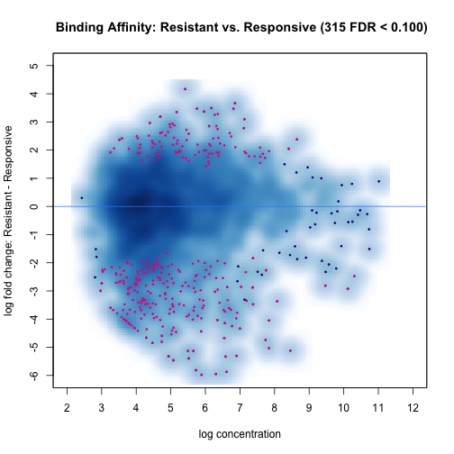

# PCA plot

## All

The following graphic is a PCA plot using the affinity data for all sites.

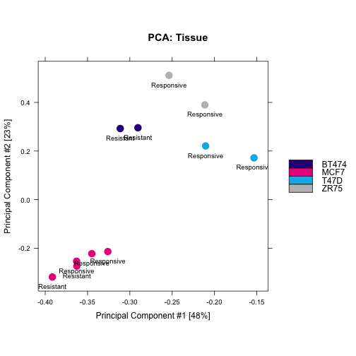

## Only DB

The following graphic is a PCA plot only using the differentially bound sites.

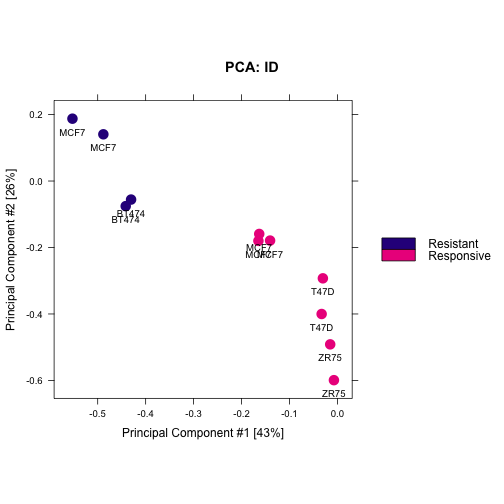

The MA and PCA plots are further described in the [DiffBind vignette](http://bioconductor.org/packages/release/bioc/vignettes/DiffBind/inst/doc/DiffBind.pdf).

# Reproducibility

This report was generated in path /Users/lcollado/Dropbox/JHSPH/Code/regionReportSupp using the following call to `renderReport()`:

```r
## renderReport(regions = regions, project = "Example DiffBind",
##     pvalueVars = c(`Q-values` = "FDR", `P-values` = "p.value"),
##     densityVars = c(Fold = "Fold", `Mean concentration` = "Conc",
##         `Concentration (resistant)` = "Conc_Resistant", `Concentration (responsive)` = "Conc_Responsive"),
##     significantVar = regions$FDR < 0.1, annotation = annotation,
##     nBestRegions = 100, customCode = file.path(getwd(), "DiffBind_custom.Rmd"),
##     outdir = "DiffBind-example", output = "index", densityTemplates = densityTemplates)
```

Date the report was generated.

```r
## [1] "2015-07-02 14:00:48 CEST"
```

Wallclock time spent generating the report.

```r
## Time difference of 47.178 secs
```

`R` session information.

```r
## Session info -----------------------------------------------------------------------------------------------------------
```

```r
##  setting  value
##  version  R version 3.2.0 Patched (2015-05-18 r68382)
##  system   x86_64, darwin10.8.0
##  ui       X11
##  language (EN)
##  collate  en_US.UTF-8
##  tz       Europe/Vienna
```

```r
## Packages ---------------------------------------------------------------------------------------------------------------
```

```r
##  package                           * version    date       source
##  acepack                             1.3-3.3    2014-11-24 CRAN (R 3.2.0)
##  amap                                0.8-14     2014-12-17 CRAN (R 3.2.0)
##  annotate                            1.47.0     2015-04-17 Bioconductor
##  AnnotationDbi                     * 1.31.16    2015-06-10 Bioconductor
##  AnnotationForge                     1.11.3     2015-05-22 Bioconductor
##  base64enc                           0.1-2      2014-06-26 CRAN (R 3.2.0)
##  BatchJobs                           1.6        2015-03-18 CRAN (R 3.2.0)
##  BBmisc                              1.9        2015-02-03 CRAN (R 3.2.0)
##  bibtex                              0.4.0      2014-12-31 CRAN (R 3.2.0)
##  Biobase                           * 2.29.1     2015-05-03 Bioconductor
##  BiocGenerics                      * 0.15.2     2015-06-05 Bioconductor
##  BiocInstaller                       1.19.6     2015-06-10 Bioconductor
##  BiocParallel                        1.3.25     2015-06-12 Bioconductor
##  biomaRt                             2.25.1     2015-04-21 Bioconductor
##  Biostrings                        * 2.37.2     2015-05-07 Bioconductor
##  biovizBase                          1.17.1     2015-05-13 Bioconductor
##  bitops                              1.0-6      2013-08-17 CRAN (R 3.2.0)
##  brew                                1.0-6      2011-04-13 CRAN (R 3.2.0)
##  BSgenome                            1.37.1     2015-04-19 Bioconductor
##  bumphunter                        * 1.9.1      2015-05-05 Bioconductor
##  Category                            2.35.1     2015-05-13 Bioconductor
##  caTools                             1.17.1     2014-09-10 CRAN (R 3.2.0)
##  checkmate                           1.5.3      2015-05-13 CRAN (R 3.2.0)
##  cluster                             2.0.1      2015-01-31 CRAN (R 3.2.0)
##  codetools                           0.2-11     2015-03-10 CRAN (R 3.2.0)
##  colorspace                          1.2-6      2015-03-11 CRAN (R 3.2.0)
##  curl                                0.9        2015-06-19 CRAN (R 3.2.1)
##  DBI                               * 0.3.1      2014-09-24 CRAN (R 3.2.0)
##  derfinder                         * 1.3.3      2015-06-15 Bioconductor
##  derfinderHelper                     1.3.0      2015-04-17 Bioconductor
##  derfinderPlot                     * 1.3.4      2015-07-01 Bioconductor
##  devtools                            1.8.0      2015-05-09 CRAN (R 3.2.0)
##  dichromat                           2.0-0      2013-01-24 CRAN (R 3.2.0)
##  DiffBind                          * 1.15.3     2015-05-21 Bioconductor
##  digest                              0.6.8      2014-12-31 CRAN (R 3.2.0)
##  doRNG                               1.6        2014-03-07 CRAN (R 3.2.0)
##  edgeR                               3.11.2     2015-05-25 Bioconductor
##  evaluate                            0.7        2015-04-21 CRAN (R 3.2.0)
##  fail                                1.2        2013-09-19 CRAN (R 3.2.0)
##  foreach                           * 1.4.2      2014-04-11 CRAN (R 3.2.0)
##  foreign                             0.8-63     2015-02-20 CRAN (R 3.2.0)
##  formatR                             1.2        2015-04-21 CRAN (R 3.2.0)
##  Formula                             1.2-1      2015-04-07 CRAN (R 3.2.0)
##  futile.logger                       1.4.1      2015-04-20 CRAN (R 3.2.0)
##  futile.options                      1.0.0      2010-04-06 CRAN (R 3.2.0)
##  gdata                               2.16.1     2015-05-01 CRAN (R 3.2.0)
##  genefilter                          1.51.0     2015-04-17 Bioconductor
##  GenomeInfoDb                      * 1.5.7      2015-06-02 Bioconductor
##  GenomicAlignments                 * 1.5.9      2015-05-13 Bioconductor
##  GenomicFeatures                   * 1.21.13    2015-06-09 Bioconductor
##  GenomicFiles                        1.5.3      2015-05-13 Bioconductor
##  GenomicRanges                     * 1.21.15    2015-06-09 Bioconductor
##  GGally                              0.5.0      2014-12-02 CRAN (R 3.2.0)
##  ggbio                             * 1.17.1     2015-05-14 Bioconductor
##  ggplot2                           * 1.0.1.9000 2015-06-12 Github (hadley/ggplot2@3b6a126)
##  git2r                               0.10.1     2015-05-07 CRAN (R 3.2.0)
##  GO.db                               3.1.2      2015-05-19 Bioconductor
##  GOstats                             2.35.1     2015-06-07 Bioconductor
##  gplots                              2.17.0     2015-05-02 CRAN (R 3.2.0)
##  graph                               1.47.2     2015-06-10 Bioconductor
##  gridExtra                         * 0.9.1      2012-08-09 CRAN (R 3.2.0)
##  GSEABase                            1.31.3     2015-06-07 Bioconductor
##  gtable                              0.1.2      2012-12-05 CRAN (R 3.2.0)
##  gtools                              3.5.0      2015-05-29 CRAN (R 3.2.0)
##  highr                               0.5        2015-04-21 CRAN (R 3.2.0)
##  Hmisc                               3.16-0     2015-04-30 CRAN (R 3.2.0)
##  htmltools                           0.2.6      2014-09-08 CRAN (R 3.2.0)
##  httr                                1.0.0      2015-06-25 CRAN (R 3.2.1)
##  hwriter                             1.3.2      2014-09-10 CRAN (R 3.2.0)
##  IRanges                           * 2.3.12     2015-06-16 Bioconductor
##  iterators                         * 1.0.7      2014-04-11 CRAN (R 3.2.0)
##  KernSmooth                          2.23-14    2015-02-11 CRAN (R 3.2.0)
##  knitcitations                       1.0.6      2015-05-26 CRAN (R 3.2.0)
##  knitr                             * 1.10.5     2015-05-06 CRAN (R 3.2.0)
##  knitrBootstrap                      1.0.0      2015-06-09 Github (jimhester/knitrBootstrap@76c41f0)
##  labeling                            0.3        2014-08-23 CRAN (R 3.2.0)
##  lambda.r                            1.1.7      2015-03-20 CRAN (R 3.2.0)
##  lattice                             0.20-31    2015-03-30 CRAN (R 3.2.0)
##  latticeExtra                        0.6-26     2013-08-15 CRAN (R 3.2.0)
##  limma                             * 3.25.9     2015-06-09 Bioconductor
##  locfit                            * 1.5-9.1    2013-04-20 CRAN (R 3.2.0)
##  lubridate                           1.3.3      2013-12-31 CRAN (R 3.2.0)
##  magrittr                            1.5        2014-11-22 CRAN (R 3.2.0)
##  markdown                            0.7.7      2015-04-22 CRAN (R 3.2.0)
##  MASS                                7.3-40     2015-03-21 CRAN (R 3.2.0)
##  Matrix                              1.2-1      2015-06-01 CRAN (R 3.2.0)
##  matrixStats                         0.14.0     2015-02-14 CRAN (R 3.2.0)
##  memoise                             0.2.1      2014-04-22 CRAN (R 3.2.0)
##  mgcv                              * 1.8-6      2015-03-31 CRAN (R 3.2.0)
##  mime                                0.3        2015-03-29 CRAN (R 3.2.0)
##  munsell                             0.4.2      2013-07-11 CRAN (R 3.2.0)
##  nlme                              * 3.1-120    2015-02-20 CRAN (R 3.2.0)
##  nnet                                7.3-9      2015-02-11 CRAN (R 3.2.0)
##  OrganismDbi                         1.11.32    2015-06-10 Bioconductor
##  pheatmap                            1.0.2      2015-03-10 CRAN (R 3.2.0)
##  pkgmaker                            0.22       2014-05-14 CRAN (R 3.2.0)
##  plyr                                1.8.3      2015-06-12 CRAN (R 3.2.0)
##  proto                               0.3-10     2012-12-22 CRAN (R 3.2.0)
##  qvalue                              2.1.0      2015-04-17 Bioconductor
##  R6                                  2.0.1      2014-10-29 CRAN (R 3.2.0)
##  RBGL                                1.45.1     2015-05-13 Bioconductor
##  RColorBrewer                      * 1.1-2      2014-12-07 CRAN (R 3.2.0)
##  Rcpp                                0.11.6     2015-05-01 CRAN (R 3.2.0)
##  RCurl                               1.95-4.6   2015-04-24 CRAN (R 3.2.0)
##  RefManageR                          0.8.63     2015-06-09 CRAN (R 3.2.0)
##  regionReport                      * 1.3.8      2015-07-01 Bioconductor
##  registry                            0.2        2012-01-24 CRAN (R 3.2.0)
##  reshape                             0.8.5      2014-04-23 CRAN (R 3.2.0)
##  reshape2                            1.4.1      2014-12-06 CRAN (R 3.2.0)
##  rjson                               0.2.15     2014-11-03 CRAN (R 3.2.0)
##  RJSONIO                             1.3-0      2014-07-28 CRAN (R 3.2.0)
##  rmarkdown                           0.7        2015-06-13 CRAN (R 3.2.0)
##  rngtools                            1.2.4      2014-03-06 CRAN (R 3.2.0)
##  rpart                               4.1-9      2015-02-24 CRAN (R 3.2.0)
##  Rsamtools                         * 1.21.8     2015-06-03 Bioconductor
##  RSQLite                           * 1.0.0      2014-10-25 CRAN (R 3.2.0)
##  rtracklayer                         1.29.10    2015-06-13 Bioconductor
##  rversions                           1.0.1      2015-06-06 CRAN (R 3.2.0)
##  S4Vectors                         * 0.7.6      2015-06-16 Bioconductor
##  scales                              0.2.5      2015-06-12 CRAN (R 3.2.0)
##  sendmailR                           1.2-1      2014-09-21 CRAN (R 3.2.0)
##  ShortRead                           1.27.4     2015-05-19 Bioconductor
##  stringi                             0.5-5      2015-06-29 CRAN (R 3.2.1)
##  stringr                             1.0.0      2015-04-30 CRAN (R 3.2.0)
##  SummarizedExperiment              * 0.1.5      2015-05-17 Bioconductor
##  survival                            2.38-2     2015-06-12 CRAN (R 3.2.0)
##  systemPipeR                         1.3.4      2015-05-21 Bioconductor
##  TxDb.Hsapiens.UCSC.hg19.knownGene * 3.1.3      2015-05-19 Bioconductor
##  VariantAnnotation                   1.15.13    2015-06-14 Bioconductor
##  whisker                           * 0.3-2      2013-04-28 CRAN (R 3.2.0)
##  XML                                 3.98-1.2   2015-05-31 CRAN (R 3.2.0)
##  xml2                                0.1.1      2015-06-02 CRAN (R 3.2.0)
##  xtable                              1.7-4      2014-09-12 CRAN (R 3.2.0)
##  XVector                           * 0.9.1      2015-04-30 Bioconductor
##  yaml                                2.1.13     2014-06-12 CRAN (R 3.2.0)
##  zlibbioc                            1.15.0     2015-04-17 Bioconductor
```

# Bibliography

This report was created with `regionReport` ([Collado-Torres, Jaffe, and Leek, 2015](http://www.bioconductor.org/packages/release/bioc/html/regionReport.html)) using `knitrBootstrap` ([Hester, 2014](https://github.com/jimhester/)) to format the html while `knitr` ([Xie, 2014](http://www.crcpress.com/product/isbn/9781466561595)) and `rmarkdown` ([Allaire, Cheng, Xie, McPherson, et al., 2015](http://CRAN.R-project.org/package=rmarkdown)) were running behind the scenes. `whisker` ([de Jonge, 2013](http://CRAN.R-project.org/package=whisker)) was used for creating templates for the `pvalueVars` and `densityVars`.

Citations made with `knitcitations` ([Boettiger, 2015](http://CRAN.R-project.org/package=knitcitations)). The [BibTeX](http://www.bibtex.org/) file can be found here.

[1] J. Allaire, J. Cheng, Y. Xie, J. McPherson, et al. *rmarkdown: Dynamic Documents for R*. R package version 0.7. 2015. URL: http://CRAN.R-project.org/package=rmarkdown.

[2] C. Boettiger. *knitcitations: Citations for Knitr Markdown Files*. R package version 1.0.6. 2015. URL: http://CRAN.R-project.org/package=knitcitations.

[3] L. Collado-Torres, A. C. Frazee, M. I. Love, R. A. Irizarry, et al. “derfinder: Software for annotation-agnostic RNA-seq differential expression analysis”. In: *bioRxiv* (2015). DOI: 10.1101/015370. URL: http://www.biorxiv.org/content/early/2015/02/19/015370.abstract.

[4] L. Collado-Torres, A. E. Jaffe and J. T. Leek. *derfinderPlot: Plotting functions for derfinder*. https://github.com/leekgroup/derfinderPlot - R package version 1.3.4. 2015. URL: http://www.bioconductor.org/packages/release/bioc/html/derfinderPlot.html.

[5] L. Collado-Torres, A. E. Jaffe and J. T. Leek. *regionReport: Generate HTML reports for exploring a set of regions*. https://github.com/leekgroup/regionReport - R package version 1.3.8. 2015. URL: http://www.bioconductor.org/packages/release/bioc/html/regionReport.html.

[6] J. Hester. *knitrBootstrap: Knitr Bootstrap framework.* R package version 1.0.0. 2014. URL: https://github.com/jimhester/.

[7] A. E. Jaffe, P. Murakami, H. Lee, J. T. Leek, et al. “Bump hunting to identify differentially methylated regions in epigenetic epidemiology studies”. In: *International journal of epidemiology* 41.1 (2012), pp. 200–209. DOI: 10.1093/ije/dyr238.

[8] E. de Jonge. *whisker: mustache for R, logicless templating*. R package version 0.3-2. 2013. URL: http://CRAN.R-project.org/package=whisker.

[9] H. Wickham. *ggplot2: elegant graphics for data analysis*. Springer New York, 2009. ISBN: 978-0-387-98140-6. URL: http://had.co.nz/ggplot2/book.

[10] Y. Xie. “knitr: A Comprehensive Tool for Reproducible Research in R”. In: *Implementing Reproducible Computational Research*. Ed. by V. Stodden, F. Leisch and R. D. Peng. ISBN 978-1466561595. Chapman and Hall/CRC, 2014. URL: http://www.crcpress.com/product/isbn/9781466561595.

[11] T. Yin, D. Cook and M. Lawrence. “ggbio: an R package for extending the grammar of graphics for genomic data”. In: *Genome Biology* 13.8 (2012), p. R77.

Styled with knitrBootstrap